# Reproducible research. Project1

Darima Butitova

5/2/2019

# Loading and preprocessing the data

Setting the working directory to access the data and loading activity.cvs. Looking at the structure of the dataset and summary of variables.

```r
data <- read.csv("activity.csv", header=TRUE)
summary(data)
```

```
##      steps                date          interval
##  Min.   :  0.00   2012-10-01:  288   Min.   :   0.0
##  1st Qu.:  0.00   2012-10-02:  288   1st Qu.: 588.8
##  Median :  0.00   2012-10-03:  288   Median :1177.5
##  Mean   : 37.38   2012-10-04:  288   Mean   :1177.5
##  3rd Qu.: 12.00   2012-10-05:  288   3rd Qu.:1766.2
##  Max.   :806.00   2012-10-06:  288   Max.   :2355.0
##  NA's   :2304     (Other)   :15840
```

```r
str(data)
```

```
## 'data.frame':    17568 obs. of  3 variables:
##  $ steps   : int  NA NA NA NA NA NA NA NA NA NA ...
##  $ date    : Factor w/ 61 levels "2012-10-01","2012-10-02",..: 1 1 1 1 1 1 1 1 1 1 ...
##  $ interval: int  0 5 10 15 20 25 30 35 40 45 ...
```

# What is mean total number of steps taken per day?

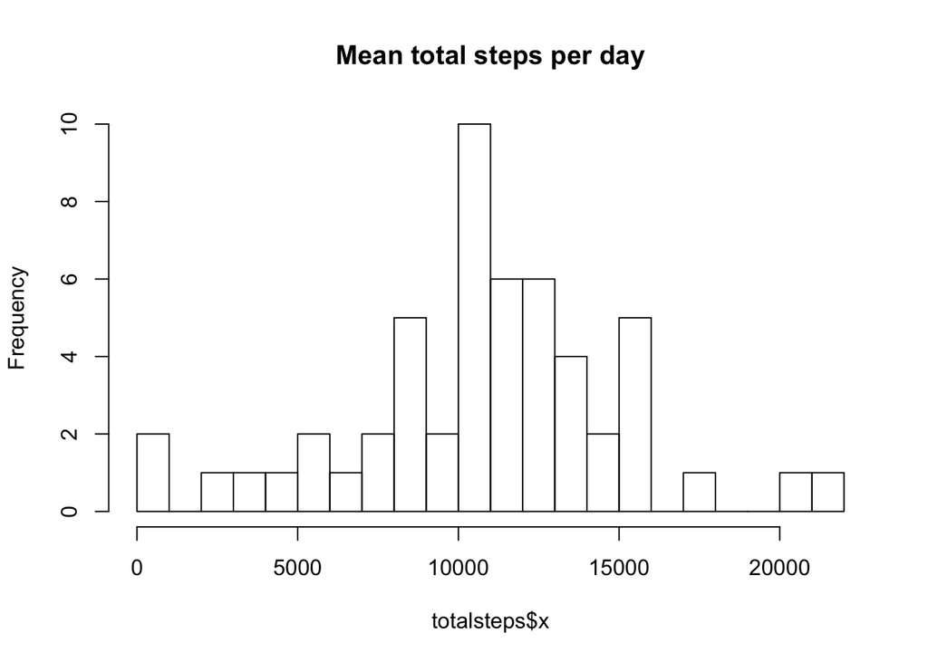

```r
totalsteps <- aggregate(data$steps, list(date=data$date), sum)
par(mfrow=c(1,1))
hist(totalsteps$x, breaks=20, main= "Mean total steps per day")
```

```r
summary(totalsteps)
```

```
##          date          x
##  2012-10-01: 1   Min.   :   41
##  2012-10-02: 1   1st Qu.: 8841
##  2012-10-03: 1   Median :10765
##  2012-10-04: 1   Mean   :10766
##  2012-10-05: 1   3rd Qu.:13294
##  2012-10-06: 1   Max.   :21194
##  (Other)   :55   NA's   :8
```

Mean of total number of steps per day is 10766, median is 10765.

# What is the average daily activity pattern?

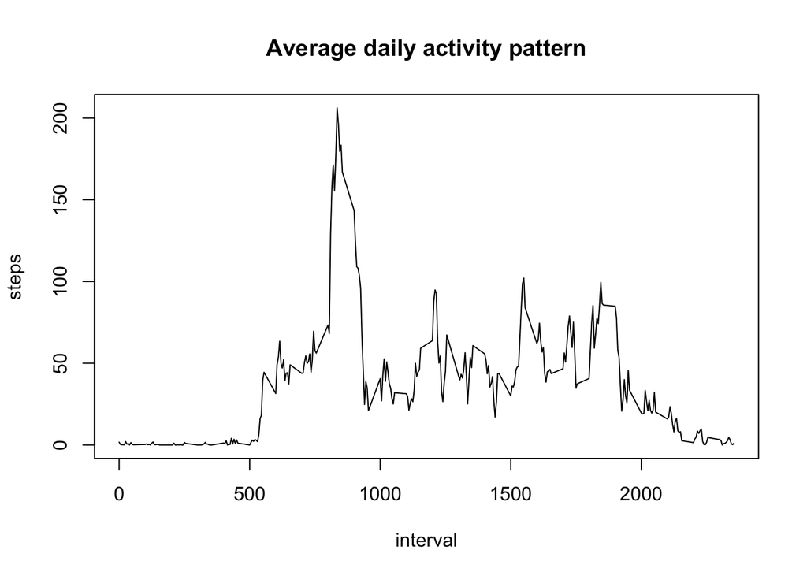

```r
datanoNA <- na.omit(data)
meanstepsbyinterval <- aggregate(datanoNA$steps, list(interval=datanoNA$interval), mean)
par(mfrow=c(1,1))
plot(meanstepsbyinterval$interval, meanstepsbyinterval$x, type="l", main="Average daily activity pattern", xlab="interval", ylab="steps")
```

```r
which.max(meanstepsbyinterval$x)
```

```
## [1] 104
```

```r
meanstepsbyinterval[104,]
```

```
##     interval        x
## 104      835 206.1698
```

Interval #104 which corresponds to 8.35am contains maximum number of steps - 206. Looks like the individual is commuting to work.

# Imputing missing values

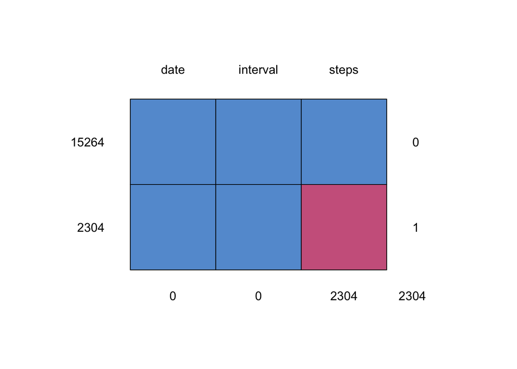

```
##       date interval steps
## 15264    1        1     1    0
## 2304     1        1     0    1
##          0        0  2304 2304
```

```r
library(mice)
md.pattern(data)
```

```r
mdata<-data
mdata <-cbind(mdata, meansteps=meanstepsbyinterval$x)
mdata$steps[is.na(mdata$steps)] <- mdata$meansteps[is.na(mdata$steps)]
mtotalsteps <- aggregate(mdata$steps, list(date=mdata$date), sum)
summary(mtotalsteps)
```

```
##          date          x
##  2012-10-01: 1   Min.   :   41
##  2012-10-02: 1   1st Qu.: 9819
##  2012-10-03: 1   Median :10766
##  2012-10-04: 1   Mean   :10766
##  2012-10-05: 1   3rd Qu.:12811
##  2012-10-06: 1   Max.   :21194
##  (Other)   :55
```

There are 2304 missing values, and they are all in “steps” variable. Missing values are replaced with the mean for the missed interval.

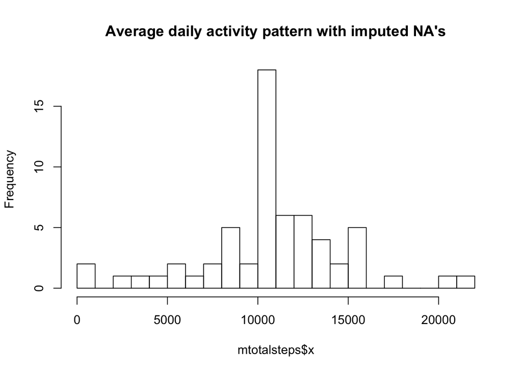

```r
par(mfrow=c(1,1))

hist(mtotalsteps$x, breaks=20, main="Average daily activity pattern with imputed NA's")
```

# Are there differences in activity patterns between weekdays and weekends?

```r
library(dplyr)
dfactor <- as.factor(weekdays(as.Date(data$date)))
dd <- recode(dfactor, Saturday=1, Sunday=1, .default=0)
mdata <- cbind(mdata, dd)

mdataweekend <- mdata[dd==1,]
meanstepsbyintwend <- aggregate(mdataweekend$steps, list(interval=mdataweekend$interval), mean)

mdataweekday <- mdata[dd==0,]
meanstepsbyintwday <- aggregate(mdataweekday$steps, list(interval=mdataweekday$interval), mean)
```

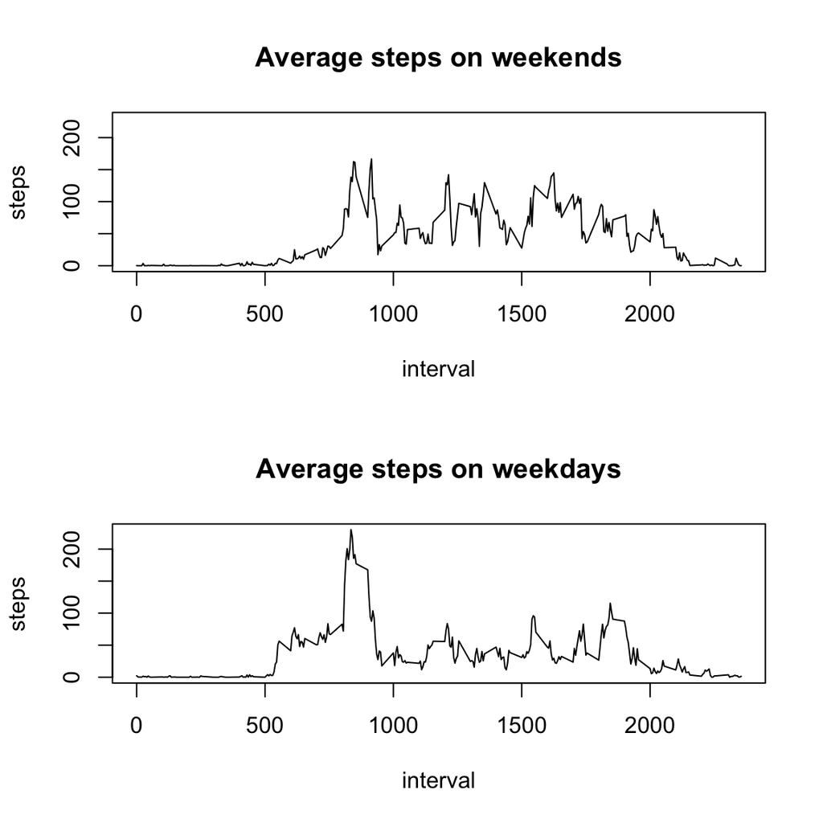

```r
par(mfrow=c(2,1))

plot(meanstepsbyintwend$interval, meanstepsbyintwend$x, type="l", main="Average steps on weekends", xlab="interval", ylab="steps", ylim=c(0, 230))
plot(meanstepsbyintwday$interval, meanstepsbyintwday$x, type="l", main="Average steps on weekdays", xlab="interval", ylab="steps", ylim=c(0, 230))
```

The pattern of activity differs on weekdays and weekends. The individual is relatively active in the morning on weekdays, most likely commuting to work, and less active the rest of the day. On weekends the individual is quite active throughout the day.